# Rendu Travaux Pratiques 4

#### Exercice 1:

```r
library(magrittr)
```

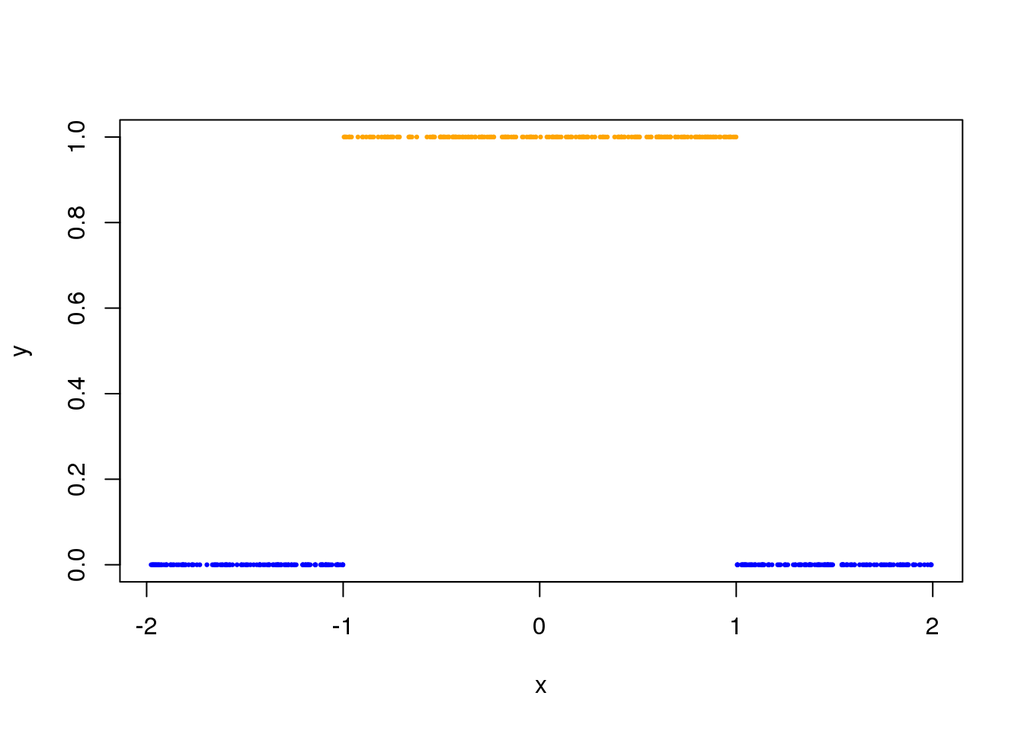

```r
set.seed(seed = 10100101)

# runif génere des points uniformément répartis entre -2 et 2
  n <- 500
  x <- runif(n, -2, 2)

# les valeurs 0 et 1 sont des valeurs logiques converties en couleurs
  y <- x > -1  &  x < 1
  color <- rep("blue", n)
  color[y] <- "orange"

# affichage des classes
  plot(x, y, pch = 19, cex = .3, col = color)
```

- Construire une fonction mathématique correspondant à un réseau ayant deux neurones cachés, permettant d’approcher la probabilité conditionnelle $p(y=1|x)$ de manière arbitrairement précise.

```r
# on créer la fonction sigmoïde qui permet de simuler un neurone
  sigmoid <- function(x){
    if (!is.numeric(x)) stop("x must be numeric.")
    return( 1/(1+exp(-x)) )
  }

# on crée la fonction f qui permet d'approcher de facon arbitrairement précise (epsilon )la fonction unité sur [-1,1]
# la fonction d'activation du réseau de neurone crée va tendre vers f, car c'est la classification optimale dans ce cas
a=1
  f <- function(x, epsilon = 0.05){
    return(a*sigmoid((1-x)/epsilon) + a*sigmoid((x+1)/epsilon) - 1)
  }
```

- Pour les données de l’exercice, vérifier le résultat en ajustant un réseau à deux neurones avec la bibliothèque `nnet`. Représenter graphiquement les valeurs prédites par le réseau de neurones et superposer la courbe de la fonction mathématique proposée.

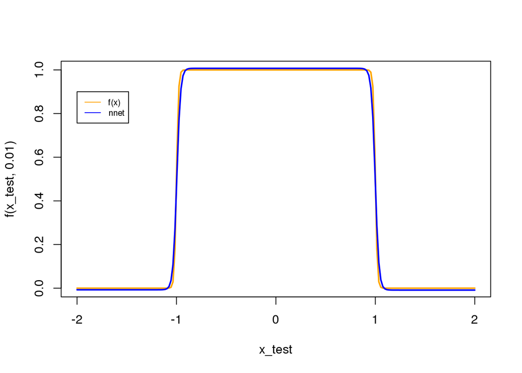

```r
#  on entraine un réseau de deux neurones qui permet de classer des données dans "blue" ou "orange"
  mod_nnet <- nnet::nnet(x,
                         color=="orange",
                         size = 2,
                         lin = TRUE,
                         decay = 0.0001,
                         trace = FALSE)

  # création échantillon de test et des prédictions de leur classe via le modèle nnet
  x_test <- seq(-2, 2, length = 200)

# on superpose les deux courbes: on observe que la fonction d'activation du réseau de neurone est très proche de f
  plot(x_test, f(x_test,0.01), type = "l", lwd = 2, col = "orange")

  pred_class <- predict(mod_nnet, matrix(x_test))
  points(x_test, pred_class, type = "l", lwd = 2, col = 4)

  legend(x= -2, y = 0.9, legend = c("f(x)", "nnet"),
       col = c("orange", "blue"), lty = 1, cex = .7)
```

- Pour l’échantillon d’apprentissage, calculer l’erreur de classification du réseau de neurones à 2 neurones cachés ajusté à la question précédente.

```r
# on calcule le pourcentage d'erreur qu'effectue le réseau de neurones sur le training set
  prob_class <- mod_nnet %>% predict()
  cat("Erreur de classification :\n")
```

```
## Erreur de classification :
```

```r
  mean( y != (prob_class > 0.5) )
```

```
## [1] 0.002
```

#### Exercice 2:

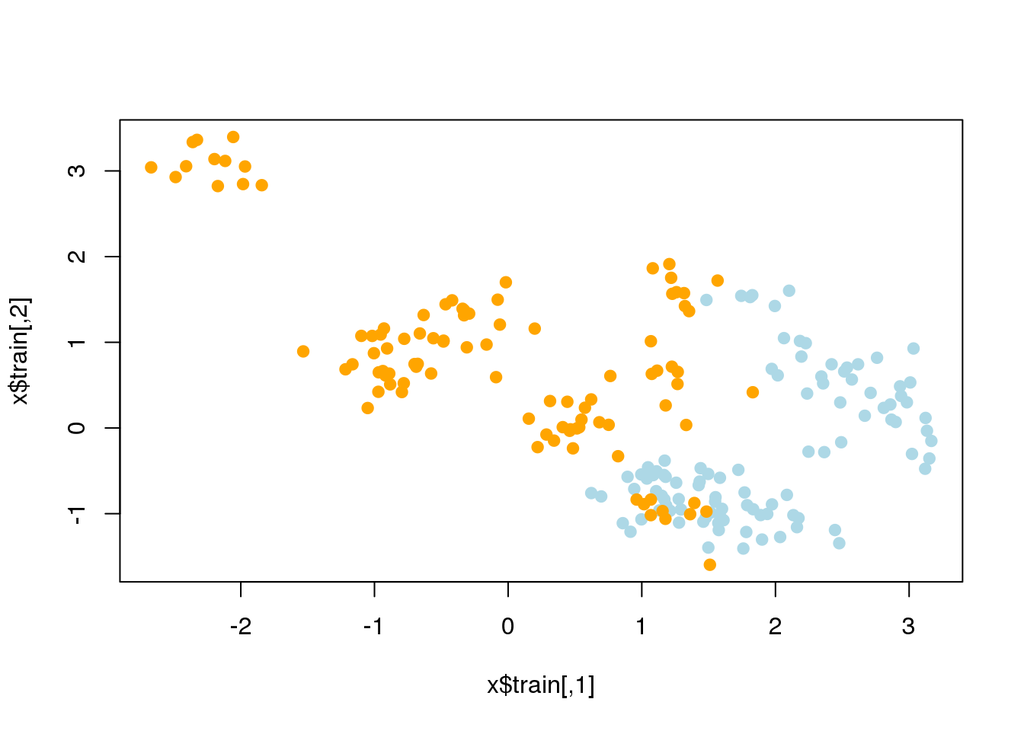

```r
library(isd)
library(keras)
library(magrittr)

## on simule des données train et test
  x <- rhastib(n_train = 200,
               n_test = 200,
               n_subclass = 10,
               sigma2 = 0.05)

  plot(x$train, pch = 19, col = x$class_train)
```

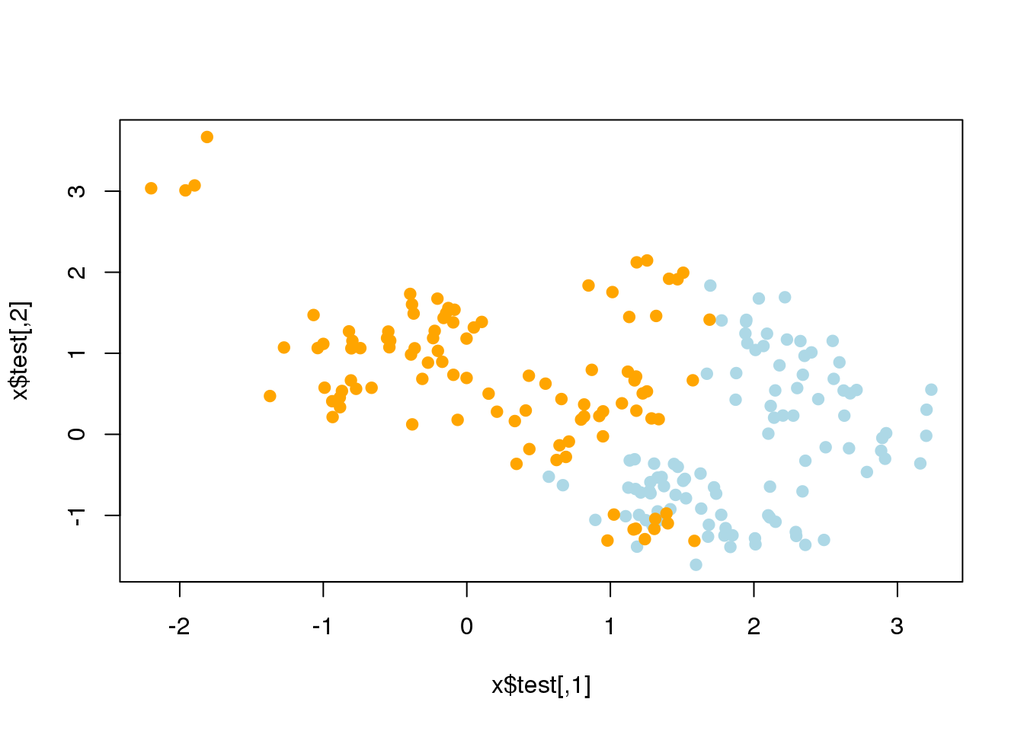

```r
  plot(x$test, pch = 19, col = x$class_test)
```

- Visualiser un historique d’entrainement d’un réseau de neurones keras. On choisira 100 neurones par exemple.

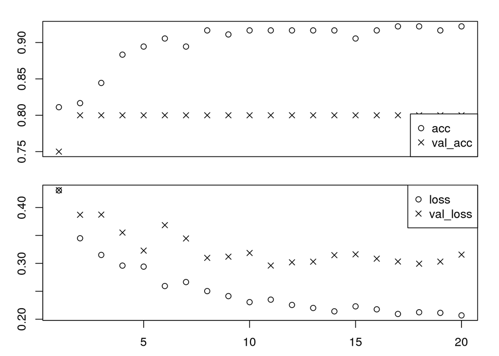

```r
plot(history)
```

**Important :** Pour la lisibilité du rapport, on utilisera l’option de chunck *include = FALSE* pour l’entrainement du réseau de neurones.

- Evaluer le modèle précédent en reportant les erreurs de classification et de perte log loss obtenues pour votre ensemble test.

```r
#on compare la classe prédite avec la vrai classe sur l'ensemble de test: c'est une matrice de confusion

pred_class <- model %>% predict_classes(x_test)
table(pred_class, y_test[,2])
```

```
##
## pred_class  0  1
##          0 98 16
##          1  2 84
```

```r
# on regarde aussi l'accuracy (qui est grande) et la log loss (qui est faible), on conclut que le modèle est performant
model %>% evaluate(x_test, y_test)
```

```
## $loss
## [1] 0.2222287
##
## $acc
## [1] 0.91
```

- Visualiser la frontière prédite entre les deux classes orange et bleue pour votre ensemble test.

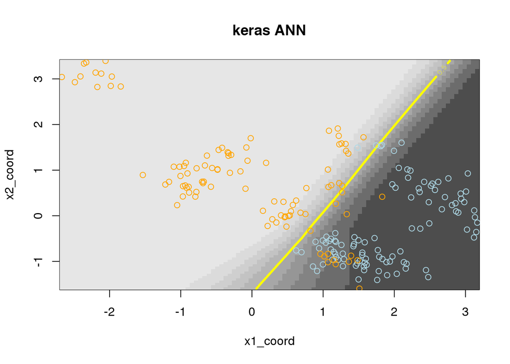

```r
## discretisation de l'ensemble d'étude

  x1_coord <- seq(min(x$train[,1]), max(x$train[,1]), length = 100)
  x2_coord <- seq(min(x$train[,2]), max(x$train[,2]), length = 100)

  matrice_test <- cbind(rep(x1_coord, length = 100),
                       rep(x2_coord, each = 100))

## on applique le modèle sur la matrice test, ce qui nous permet de visualiser comment le modèle classe les points
## dans l'intervalle (rectangle) dans lequel les points d'entrainement sont compris

  prob_class <- model %>% predict_proba(matrice_test)
  prob_class <- prob_class[,2] %>% matrix(nrow = 100)

## on visualise donc le rectangle avec différents niveau de gris suivant la probabilité de classification
## ainsi que les points du training test colorés dans la couleur de leur classe
## ainsi que la droite limite calculée par le modèle qui permet de prendre la décision de classification

  image(x1_coord, x2_coord, prob_class, col = grey.colors(10), main = "keras ANN")
  contour(x1_coord, x2_coord, prob_class, levels = c(0.5), col = "yellow", lwd = 3, add = TRUE)
  points(x$train, col = x$class_train)
```

#### Exercice 3: Défi “MNIST 1-2-7”

**Important :** Pour la lisibilité du rapport, on utilisera l’option de chunck *include = FALSE* pour l’entrainement des réseaux de neurones.

```r
#on récupère les données minst
mnist <- dataset_mnist()
  x_train <- mnist$train$x
  y_train <- mnist$train$y
  x_test <- mnist$test$x
  y_test <- mnist$test$y

# on ne garde que les données correspondant aux 1,2 ou 7

  boo_tr <- y_train == 1 | y_train == 2 | y_train == 7
  x_train <- mnist$train$x[boo_tr,,]
  y_train <- mnist$train$y[boo_tr]

  boo_te <- y_test == 1 | y_test == 2 | y_test == 7
  x_test <- mnist$test$x[boo_te,,]
  y_test <- mnist$test$y[boo_te]

# reshape
  x_train <- array_reshape(x_train, c(nrow(x_train), 784))
  x_test <- array_reshape(x_test, c(nrow(x_test), 784))

# rescale
  x_train <- x_train/255
  x_test <- x_test/255

# on veut stocker les classes de manière catégorielle
  y_train <- y_train %>% factor() %>% as.integer() %>% -1 %>% to_categorical(3)
  y_test <-  y_test %>% factor() %>% as.integer() %>% -1 %>% to_categorical(3)
```

- Reporter dans un tableau 12x2, les valeurs des erreurs de classification et de logloss obtenues sur l’ensemble test pour 12 réseaux de neurones distincts dont on aura fait varier les paramètres (nombre de couches cachées : 1 à 3, nombre de neurones par couche cachée : 10 et 100, valeurs de dropout : 0.2 et 0.5)

```r
#on crée 3 fonctions qui permettent d'entrainer et d'appliquer un modèle suivant différent paramètres
#nb neurones et dropout. f1 contiendra 1 couche de neurone alors que f3 en a 3.
f1 = function(nb_neurones, dropout){
  model <- keras_model_sequential()
  model %>%
    layer_dense(units = nb_neurones, activation = 'relu', input_shape = 784) %>%
    layer_dropout(rate = dropout) %>%
    layer_dense(units = 3, activation = 'softmax')

  model %>% compile(
    loss = 'categorical_crossentropy',
    optimizer = optimizer_rmsprop(lr = 0.001, decay = 0),
    metrics = c('accuracy')
)

  history <- model %>% fit(
                        x_train,
                        y_train,
                        epochs = 20,
                        batch_size = 128,
                        validation_split = 0.2
)
perf = model %>% evaluate(x_test, y_test)
return(perf)
}

f2 = function(nb_neurones, dropout){
  model <- keras_model_sequential()
  model %>%
    layer_dense(units = nb_neurones, activation = 'relu', input_shape = 784) %>%
    layer_dropout(rate = dropout) %>%
    layer_dense(units = nb_neurones, activation = 'relu') %>%
    layer_dropout(rate = dropout) %>%
    layer_dense(units = 3, activation = 'softmax')

  model %>% compile(
    loss = 'categorical_crossentropy',
    optimizer = optimizer_rmsprop(lr = 0.001, decay = 0),
    metrics = c('accuracy')
)

  history <- model %>% fit(
                        x_train,
                        y_train,
                        epochs = 20,
                        batch_size = 128,
                        validation_split = 0.2
)
perf = model %>% evaluate(x_test, y_test)
return(perf)
}

f3 = function(nb_neurones, dropout){
  model <- keras_model_sequential()
  model %>%
    layer_dense(units = nb_neurones, activation = 'relu', input_shape = 784) %>%
    layer_dropout(rate = dropout) %>%
    layer_dense(units = nb_neurones, activation = 'relu') %>%
    layer_dropout(rate = dropout) %>%
    layer_dense(units = nb_neurones, activation = 'relu') %>%
    layer_dropout(rate = dropout) %>%
    layer_dense(units = 3, activation = 'softmax')


  model %>% compile(
    loss = 'categorical_crossentropy',
    optimizer = optimizer_rmsprop(lr = 0.001, decay = 0),
    metrics = c('accuracy')
)

  history <- model %>% fit(
                        x_train,
                        y_train,
                        epochs = 20,
                        batch_size = 128,
                        validation_split = 0.2
)
perf = model %>% evaluate(x_test, y_test)
return(perf)
}
```

- Quel modèle de prédiction vous parait être le meilleur ?

```r
# on met dans le tableau comparison les losses et accuracies de chaque modèle
comparison
```

```
##                      loss       acc
## modele_1_10_2  0.05842970 0.9830986
## modele_2_10_2  0.07095263 0.9852895
## modele_3_10_2  0.08266637 0.9849765
## modele_1_10_5  0.07682513 0.9818466
## modele_2_10_5  0.15506939 0.9812207
## modele_3_10_5  0.21450082 0.9784038
## modele_1_100_2 0.04680612 0.9906103
## modele_2_100_2 0.06801904 0.9915493
## modele_3_100_2 0.07468114 0.9924883
## modele_1_100_5 0.05156176 0.9899844
## modele_2_100_5 0.07517274 0.9893584
## modele_3_100_5 0.08924809 0.9890454
```

Le modèle le plus performant est le modèle 1-100-2, qui contient donc une couche dense de 100 neurones avec un dropout de 0.2.

- Pour ce modèle, quelles sont les erreurs de classification les plus fréquentes ? Quantifier ces erreurs.

```r
# on compare la prédiction du modèle avec la vrai classe des données test, dans une matrice de confusion
pred_class <- model %>% predict_classes(x_test)
table(pred_class, mnist$test$y[boo_te])
```

```
##
## pred_class    1    2    7
##          0 1130    3    6
##          1    5 1021    9
##          2    0    8 1013
```

Cela est logique étant donné que le 7 et le 2 dont bien plus proche au niveau de la forme qu’avec le 1.

A noter que les données de pred_class sont classées dans les catégories 0,1,2 qui sont en fait 1,2,7.